# ReneWind

Renewable energy sources play an increasingly important role in the global energy mix, as the effort to reduce the environmental impact of energy production increases.

Out of all the renewable energy alternatives, wind energy is one of the most developed technologies worldwide. The U.S Department of Energy has put together a guide to achieving operational efficiency using predictive maintenance practices.

Predictive maintenance uses sensor information and analysis methods to measure and predict degradation and future component capability. The idea behind predictive maintenance is that failure patterns are predictable and if component failure can be predicted accurately and the component is replaced before it fails, the costs of operation and maintenance will be much lower.

The sensors fitted across different machines involved in the process of energy generation collect data related to various environmental factors (temperature, humidity, wind speed, etc.) and additional features related to various parts of the wind turbine (gearbox, tower, blades, break, etc.).

## Objective

“ReneWind” is a company working on improving the machinery/processes involved in the production of wind energy using machine learning and has collected data of generator failure of wind turbines using sensors. They have shared a ciphered version of the data, as the data collected through sensors is confidential (the type of data collected varies with companies). Data has 40 predictors, 40000 observations in the training set and 10000 in the test set.

The objective is to build various classification models, tune them and find the best one that will help identify failures so that the generator could be repaired before failing/breaking and the overall maintenance cost of the generators can be brought down.

“1” in the target variables should be considered as “failure” and “0” will represent “No failure”.

The nature of predictions made by the classification model will translate as follows:

- True positives (TP) are failures correctly predicted by the model.
- False negatives (FN) are real failures in a wind turbine where there is no detection by model.
- False positives (FP) are detections in a wind turbine where there is no failure.

So, the maintenance cost associated with the model would be:

**Maintenance cost** = `TP*(Repair cost) + FN*(Replacement cost) + FP*(Inspection cost)` where,

- `Replacement cost = $40,000`
- `Repair cost = $15,000`
- `Inspection cost = $5,000`

Here the objective is to reduce the maintenance cost so, we want a metric that could reduce the maintenance cost.

- The minimum possible maintenance cost = `Actual failures*(Repair cost) = (TP + FN)*(Repair cost)`
- The maintenance cost associated with model = `TP*(Repair cost) + FN*(Replacement cost) + FP*(Inspection cost)`

So, we will try to maximize the ratio of minimum possible maintenance cost and the maintenance cost associated with the model.

The value of this ratio will lie between 0 and 1, the ratio will be 1 only when the maintenance cost associated with the model will be equal to the minimum possible maintenance cost.

## Data Description

- The data provided is a transformed version of original data which was collected using sensors.
- Train.csv - To be used for training and tuning of models.
- Test.csv - To be used only for testing the performance of the final best model.
- Both the datasets consist of 40 predictor variables and 1 target variable

## Importing libraries

```python
# Libraries to help with reading and manipulating data
import numpy as np
import pandas as pd

# Libraries to help with data visualization
import matplotlib.pyplot as plt
import seaborn as sns

# To tune model, get different metric scores and split data
from sklearn.model_selection import GridSearchCV, RandomizedSearchCV
from sklearn.model_selection import train_test_split, StratifiedKFold, cross_val_score
from sklearn.metrics import (
    f1_score,
    accuracy_score,
    recall_score,
    precision_score,
    confusion_matrix,
    roc_auc_score,
    plot_confusion_matrix,
)

# To impute missing values
from sklearn.impute import KNNImputer
from sklearn.impute import SimpleImputer

# To build a logistic regression model
from sklearn.linear_model import LogisticRegression

# To oversample and undersample data
from imblearn.over_sampling import SMOTE
from imblearn.under_sampling import RandomUnderSampler

# To help with model building
from sklearn.linear_model import LogisticRegression
from sklearn.tree import DecisionTreeClassifier
from sklearn.ensemble import (
    AdaBoostClassifier,
    GradientBoostingClassifier,
    RandomForestClassifier,
    BaggingClassifier,
)
from xgboost import XGBClassifier

from sklearn.tree import DecisionTreeRegressor
from sklearn.ensemble import (
    BaggingRegressor,
    RandomForestRegressor,
    GradientBoostingRegressor,
    AdaBoostRegressor,
    StackingRegressor,
)
from xgboost import XGBRegressor

# To suppress the warnings
import warnings

warnings.filterwarnings("ignore")

# This will help in making the Python code more structured automatically (good coding practice)
%reload_ext nb_black
```

## Loading Data

```python
train = pd.read_csv("Train.csv")
```

```python
# make a copy
data = train.copy()
```

## EDA and insights

```python
# explore data shape
data.shape
```

```
(40000, 41)
```

```python
# view top/bottom of data
data.head()
```

|  | V1 | V2 | V3 | V4 | V5 | V6 | V7 | V8 | V9 | V10 | ... | V32 | V33 | V34 | V35 | V36 | V37 | V38 | V39 | V40 | Target |
| --- | --- | --- | --- | --- | --- | --- | --- | --- | --- | --- | --- | --- | --- | --- | --- | --- | --- | --- | --- | --- | --- |
| 0 | -4.464606 | -4.679129 | 3.101546 | 0.506130 | -0.221083 | -2.032511 | -2.910870 | 0.050714 | -1.522351 | 3.761892 | ... | 3.059700 | -1.690440 | 2.846296 | 2.235198 | 6.667486 | 0.443809 | -2.369169 | 2.950578 | -3.480324 | 0 |
| 1 | -2.909996 | -2.568662 | 4.109032 | 1.316672 | -1.620594 | -3.827212 | -1.616970 | 0.669006 | 0.387045 | 0.853814 | ... | -3.782686 | -6.823172 | 4.908562 | 0.481554 | 5.338051 | 2.381297 | -3.127756 | 3.527309 | -3.019581 | 0 |
| 2 | 4.283674 | 5.105381 | 6.092238 | 2.639922 | -1.041357 | 1.308419 | -1.876140 | -9.582412 | 3.469504 | 0.763395 | ... | -3.097934 | 2.690334 | -1.643048 | 7.566482 | -3.197647 | -3.495672 | 8.104779 | 0.562085 | -4.227426 | 0 |
| 3 | 3.365912 | 3.653381 | 0.909671 | -1.367528 | 0.332016 | 2.358938 | 0.732600 | -4.332135 | 0.565695 | -0.101080 | ... | -1.795474 | 3.032780 | -2.467514 | 1.894599 | -2.297780 | -1.731048 | 5.908837 | -0.386345 | 0.616242 | 0 |
| 4 | -3.831843 | -5.824444 | 0.634031 | -2.418815 | -1.773827 | 1.016824 | -2.098941 | -3.173204 | -2.081860 | 5.392621 | ... | -0.257101 | 0.803550 | 4.086219 | 2.292138 | 5.360850 | 0.351993 | 2.940021 | 3.839160 | -4.309402 | 0 |

5 rows × 41 columns

```python
data.tail()
```

|  | V1 | V2 | V3 | V4 | V5 | V6 | V7 | V8 | V9 | V10 | ... | V32 | V33 | V34 | V35 | V36 | V37 | V38 | V39 | V40 | Target |
| --- | --- | --- | --- | --- | --- | --- | --- | --- | --- | --- | --- | --- | --- | --- | --- | --- | --- | --- | --- | --- | --- |
| 39995 | -3.896979 | -3.942407 | -0.351364 | -2.417462 | 1.107546 | -1.527623 | -3.519882 | 2.054792 | -0.233996 | -0.357687 | ... | 7.112162 | 1.476080 | -3.953710 | 1.855555 | 5.029209 | 2.082588 | -6.409304 | 1.477138 | -0.874148 | 0 |
| 39996 | -3.187322 | -10.051662 | 5.695955 | -4.370053 | -5.354758 | -1.873044 | -3.947210 | 0.679420 | -2.389254 | 5.456756 | ... | 0.402812 | 3.163661 | 3.752095 | 8.529894 | 8.450626 | 0.203958 | -7.129918 | 4.249394 | -6.112267 | 0 |
| 39997 | -2.686903 | 1.961187 | 6.137088 | 2.600133 | 2.657241 | -4.290882 | -2.344267 | 0.974004 | -1.027462 | 0.497421 | ... | 6.620811 | -1.988786 | -1.348901 | 3.951801 | 5.449706 | -0.455411 | -2.202056 | 1.678229 | -1.974413 | 0 |
| 39998 | 0.521278 | 0.096069 | 8.457178 | 2.137915 | -1.635866 | -2.712731 | -2.692638 | -3.410475 | 1.935682 | 2.012469 | ... | -1.256613 | -1.135704 | 1.433714 | 5.905493 | 3.751847 | -1.866539 | -1.917547 | 2.573462 | -5.018783 | 0 |
| 39999 | 2.403476 | -1.336369 | 6.450749 | -5.356242 | -0.433735 | 0.254771 | -1.119585 | -2.523423 | -0.653532 | 2.315818 | ... | -4.309840 | -0.708936 | -1.358665 | 1.639206 | 7.766085 | -0.244776 | -1.123941 | 2.872102 | 1.901951 | 0 |

5 rows × 41 columns

- Data consists of 40000 observations with 40 columns of predictor values and one column for whether the unit failed, or did not fail

```python
# checking data types
data.info()
```

```
<class 'pandas.core.frame.DataFrame'>
RangeIndex: 40000 entries, 0 to 39999
Data columns (total 41 columns):
 #   Column  Non-Null Count  Dtype
---  ------  --------------  -----
 0   V1      39954 non-null  float64
 1   V2      39961 non-null  float64
 2   V3      40000 non-null  float64
 3   V4      40000 non-null  float64
 4   V5      40000 non-null  float64
 5   V6      40000 non-null  float64
 6   V7      40000 non-null  float64
 7   V8      40000 non-null  float64
 8   V9      40000 non-null  float64
 9   V10     40000 non-null  float64
```

[output cut: 33 more lines]

- All of the observations are of float integer type, with Target column being integer in the form of 0/1
- V1 and V2 have some missing values

```python
# let's check for missing values in the data
round(data.isnull().sum() / data.isnull().count() * 100, 2)
```

```
V1        0.12
V2        0.10
V3        0.00
V4        0.00
V5        0.00
V6        0.00
V7        0.00
V8        0.00
V9        0.00
V10       0.00
V11       0.00
V12       0.00
V13       0.00
V14       0.00
V15       0.00
V16       0.00
V17       0.00
V18       0.00
V19       0.00
V20       0.00
V21       0.00
V22       0.00
V23       0.00
V24       0.00
V25       0.00
V26       0.00
V27       0.00
V28       0.00
V29       0.00
V30       0.00
V31       0.00
V32       0.00
V33       0.00
V34       0.00
V35       0.00
V36       0.00
V37       0.00
V38       0.00
V39       0.00
V40       0.00
Target    0.00
dtype: float64
```

- V1 has 0.12% missing values out of the total observations
- V2 has 0.10% missing values out of the total observations

```python
# Statistical summary of observations
data.describe()
```

|  | V1 | V2 | V3 | V4 | V5 | V6 | V7 | V8 | V9 | V10 | ... | V32 | V33 | V34 | V35 | V36 | V37 | V38 | V39 | V40 | Target |
| --- | --- | --- | --- | --- | --- | --- | --- | --- | --- | --- | --- | --- | --- | --- | --- | --- | --- | --- | --- | --- | --- |
| count | 39954.000000 | 39961.000000 | 40000.000000 | 40000.000000 | 40000.000000 | 40000.000000 | 40000.000000 | 40000.000000 | 40000.000000 | 40000.000000 | ... | 40000.000000 | 40000.000000 | 40000.000000 | 40000.000000 | 40000.000000 | 40000.000000 | 40000.000000 | 40000.000000 | 40000.000000 | 40000.000000 |
| mean | -0.288120 | 0.442672 | 2.505514 | -0.066078 | -0.044574 | -1.000849 | -0.892793 | -0.563123 | -0.007739 | -0.001848 | ... | 0.326831 | 0.056542 | -0.464127 | 2.234861 | 1.530020 | -0.000498 | -0.351199 | 0.900035 | -0.897166 | 0.054675 |
| std | 3.449072 | 3.139431 | 3.406263 | 3.437330 | 2.107183 | 2.036756 | 1.756510 | 3.298916 | 2.161833 | 2.183034 | ... | 5.499369 | 3.574219 | 3.185712 | 2.924185 | 3.819754 | 1.778273 | 3.964186 | 1.751022 | 2.997750 | 0.227348 |
| min | -13.501880 | -13.212051 | -11.469369 | -16.015417 | -8.612973 | -10.227147 | -8.205806 | -15.657561 | -8.596313 | -11.000790 | ... | -23.200866 | -17.454014 | -17.985094 | -15.349803 | -17.478949 | -7.639952 | -17.375002 | -7.135788 | -11.930259 | 0.000000 |
| 25% | -2.751460 | -1.638355 | 0.202682 | -2.349574 | -1.507206 | -2.363446 | -2.036913 | -2.660415 | -1.493676 | -1.390549 | ... | -3.392115 | -2.237550 | -2.127757 | 0.332081 | -0.937119 | -1.265717 | -3.016805 | -0.261578 | -2.949590 | 0.000000 |
| 50% | -0.773518 | 0.463939 | 2.265319 | -0.123691 | -0.096824 | -1.006635 | -0.934738 | -0.384188 | -0.052085 | 0.105779 | ... | 0.056243 | -0.049729 | -0.250842 | 2.110125 | 1.571511 | -0.132620 | -0.318724 | 0.921321 | -0.949269 | 0.000000 |
| 75% | 1.836708 | 2.537508 | 4.584920 | 2.148596 | 1.346224 | 0.373909 | 0.206820 | 1.714383 | 1.425713 | 1.486105 | ... | 3.789241 | 2.255985 | 1.432885 | 4.044659 | 3.996721 | 1.160828 | 2.291342 | 2.069016 | 1.092178 | 0.000000 |
| max | 17.436981 | 13.089269 | 18.366477 | 13.279712 | 9.403469 | 7.065470 | 8.006091 | 11.679495 | 8.507138 | 8.108472 | ... | 24.847833 | 16.692486 | 14.358213 | 16.804859 | 19.329576 | 7.803278 | 15.964053 | 7.997832 | 10.654265 | 1.000000 |

8 rows × 41 columns

```python
# median values of predictors
data.median()
```

```
V1       -0.773518
V2        0.463939
V3        2.265319
V4       -0.123691
V5       -0.096824
V6       -1.006635
V7       -0.934738
V8       -0.384188
V9       -0.052085
V10       0.105779
V11      -1.941726
V12       1.485367
V13       1.653836
V14      -0.957444
V15      -2.398608
V16      -2.718600
V17      -0.027895
V18       0.867433
V19       1.278402
V20       0.030136
V21      -3.559327
V22       0.962802
V23      -0.275339
V24       0.963586
V25       0.021100
V26       1.963826
V27      -0.909640
V28      -0.904757
V29      -1.206027
V30       0.184613
V31       0.491352
V32       0.056243
V33      -0.049729
V34      -0.250842
V35       2.110125
V36       1.571511
V37      -0.132620
V38      -0.318724
V39       0.921321
V40      -0.949269
Target    0.000000
dtype: float64
```

```python
# replace missing values with median values
data = data.apply(lambda x: x.fillna(x.median()), axis=0)
```

```python
# let's check for missing values in the data
round(data.isnull().sum() / data.isnull().count() * 100, 2)
```

```
V1        0.0
V2        0.0
V3        0.0
V4        0.0
V5        0.0
V6        0.0
V7        0.0
V8        0.0
V9        0.0
V10       0.0
V11       0.0
V12       0.0
V13       0.0
V14       0.0
V15       0.0
V16       0.0
V17       0.0
V18       0.0
V19       0.0
V20       0.0
V21       0.0
V22       0.0
V23       0.0
V24       0.0
V25       0.0
V26       0.0
V27       0.0
V28       0.0
V29       0.0
V30       0.0
V31       0.0
V32       0.0
V33       0.0
V34       0.0
V35       0.0
V36       0.0
V37       0.0
V38       0.0
V39       0.0
V40       0.0
Target    0.0
dtype: float64
```

```python
# check statistics again
data.describe()
```

|  | V1 | V2 | V3 | V4 | V5 | V6 | V7 | V8 | V9 | V10 | ... | V32 | V33 | V34 | V35 | V36 | V37 | V38 | V39 | V40 | Target |
| --- | --- | --- | --- | --- | --- | --- | --- | --- | --- | --- | --- | --- | --- | --- | --- | --- | --- | --- | --- | --- | --- |
| count | 40000.000000 | 40000.000000 | 40000.000000 | 40000.000000 | 40000.000000 | 40000.000000 | 40000.000000 | 40000.000000 | 40000.000000 | 40000.000000 | ... | 40000.000000 | 40000.000000 | 40000.000000 | 40000.000000 | 40000.000000 | 40000.000000 | 40000.000000 | 40000.000000 | 40000.000000 | 40000.000000 |
| mean | -0.288678 | 0.442693 | 2.505514 | -0.066078 | -0.044574 | -1.000849 | -0.892793 | -0.563123 | -0.007739 | -0.001848 | ... | 0.326831 | 0.056542 | -0.464127 | 2.234861 | 1.530020 | -0.000498 | -0.351199 | 0.900035 | -0.897166 | 0.054675 |
| std | 3.447128 | 3.137900 | 3.406263 | 3.437330 | 2.107183 | 2.036756 | 1.756510 | 3.298916 | 2.161833 | 2.183034 | ... | 5.499369 | 3.574219 | 3.185712 | 2.924185 | 3.819754 | 1.778273 | 3.964186 | 1.751022 | 2.997750 | 0.227348 |
| min | -13.501880 | -13.212051 | -11.469369 | -16.015417 | -8.612973 | -10.227147 | -8.205806 | -15.657561 | -8.596313 | -11.000790 | ... | -23.200866 | -17.454014 | -17.985094 | -15.349803 | -17.478949 | -7.639952 | -17.375002 | -7.135788 | -11.930259 | 0.000000 |
| 25% | -2.750028 | -1.635272 | 0.202682 | -2.349574 | -1.507206 | -2.363446 | -2.036913 | -2.660415 | -1.493676 | -1.390549 | ... | -3.392115 | -2.237550 | -2.127757 | 0.332081 | -0.937119 | -1.265717 | -3.016805 | -0.261578 | -2.949590 | 0.000000 |
| 50% | -0.773518 | 0.463939 | 2.265319 | -0.123691 | -0.096824 | -1.006635 | -0.934738 | -0.384188 | -0.052085 | 0.105779 | ... | 0.056243 | -0.049729 | -0.250842 | 2.110125 | 1.571511 | -0.132620 | -0.318724 | 0.921321 | -0.949269 | 0.000000 |
| 75% | 1.832087 | 2.534373 | 4.584920 | 2.148596 | 1.346224 | 0.373909 | 0.206820 | 1.714383 | 1.425713 | 1.486105 | ... | 3.789241 | 2.255985 | 1.432885 | 4.044659 | 3.996721 | 1.160828 | 2.291342 | 2.069016 | 1.092178 | 0.000000 |
| max | 17.436981 | 13.089269 | 18.366477 | 13.279712 | 9.403469 | 7.065470 | 8.006091 | 11.679495 | 8.507138 | 8.108472 | ... | 24.847833 | 16.692486 | 14.358213 | 16.804859 | 19.329576 | 7.803278 | 15.964053 | 7.997832 | 10.654265 | 1.000000 |

8 rows × 41 columns

### Univariate Analysis

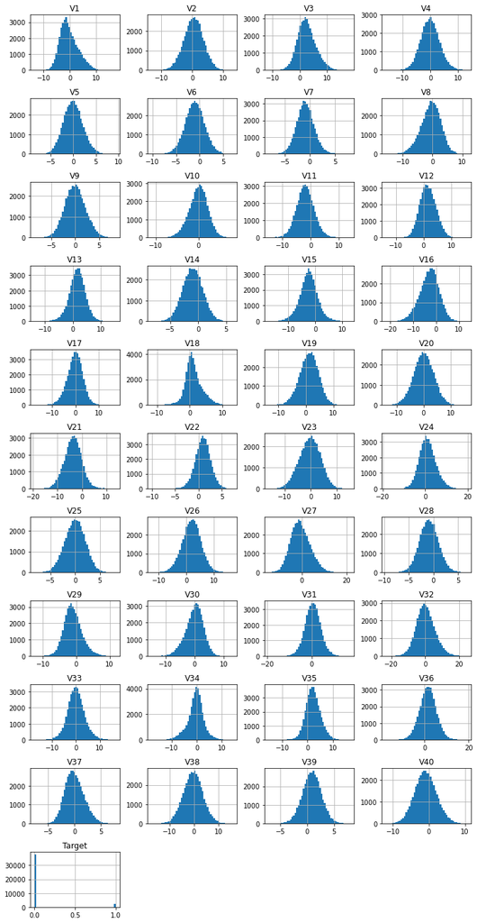

```python
fig, ax = plt.subplots(figsize=(10, 35))
for n, col in enumerate(data.columns):
    plt.subplot(20, 4, n + 1)
    data[col].hist(ax=plt.gca(), bins=50)
    plt.title(col)
    plt.axis


plt.tight_layout(pad=0.4, w_pad=0.5, h_pad=1.0)
```

```python
# function to create labeled barplots


def labeled_barplot(data, feature, perc=False, n=None):
    """
    Barplot with percentage at the top

    data: dataframe
    feature: dataframe column
    perc: whether to display percentages instead of count (default is False)
    n: displays the top n category levels (default is None, i.e., display all levels)
    """

    total = len(data[feature])  # length of the column
    count = data[feature].nunique()
    if n is None:
        plt.figure(figsize=(count + 2, 6))
    else:
        plt.figure(figsize=(n + 2, 6))

    plt.xticks(rotation=90, fontsize=15)
    ax = sns.countplot(
        data=data,
        x=feature,
        palette="Paired",
        order=data[feature].value_counts().index[:n].sort_values(),
    )

    for p in ax.patches:
        if perc == True:
            label = "{:.1f}%".format(
                100 * p.get_height() / total
            )  # percentage of each class of the category
        else:
            label = p.get_height()  # count of each level of the category

        x = p.get_x() + p.get_width() / 2  # width of the plot
        y = p.get_height()  # height of the plot

        ax.annotate(
            label,
            (x, y),
            ha="center",
            va="center",
            size=12,
            xytext=(0, 5),
            textcoords="offset points",
        )  # annotate the percentage

    plt.show()  # show the plot
```

#### Observations on Target

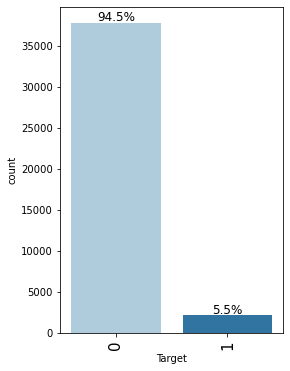

```python
labeled_barplot(data, "Target", perc=True)
```

```python
data["Target"].value_counts(normalize=True)
```

```
0    0.945325
1    0.054675
Name: Target, dtype: float64
```

- There is a fail rate of 5.5%

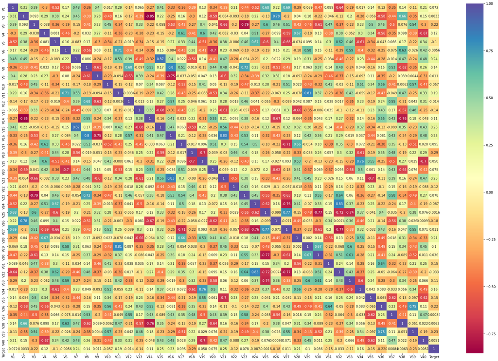

```python
plt.figure(figsize=(30, 20))
sns.heatmap(data.corr(), annot=True, cmap="Spectral")
plt.show()
```

## Data Pre-processing

#### Missing Data

- V1 had 0.12% missing values out of the total observations.
- V2 had 0.10% missing values out of the total observations.
- Missing values were removed and replaced with median values.
- Data will be split into training and validation to ensure no data leakage via exposing test set to modeling manipulations.

```python
# Making copy of dataframe
data1= data.copy()
```

```python
# dropping the y variable
X = data1.drop('Target',axis=1)
y = data1['Target']
```

```python
# Splitting data into training and validation set:
X_train, X_val, y_train, y_val = train_test_split(
    X, y, test_size=0.3, random_state=1, stratify=y
)
print(X_train.shape, X_val.shape)
```

```
(28000, 40) (12000, 40)
```

```python
print("Training")
print(y_train.value_counts(1))
print("*" * 50)
print("Validation")
print(y_val.value_counts(1))
```

```
Training
0    0.945321
1    0.054679
Name: Target, dtype: float64
Validation
0    0.945333
1    0.054667
Name: Target, dtype: float64
```

## Model evaluation criterion

### 3 types of cost are associated with the provided problem

1. Replacement cost - False Negatives - Predicting no failure, while there will be a failure
2. Inspection cost - False Positives - Predicting failure, while there is no failure
3. Repair cost - True Positives - Predicting failure correctly

### How to reduce the overall cost?

- We need to create a customized metric, that can help to bring down the overall cost.
- The cost associated with any model = TP *15000 + FP* 5000 + FN * 40000
- And the minimum possible cost will be when, the model will be able to identify all failures, in that case, the cost will be (TP + FN) * 15000
- So, we will try to maximize `Minimum cost/Cost associated with model`

**Let's create two functions to calculate different metrics and confusion matrix, so that we don't have to use the same code repeatedly for each model.**

```python
# defining a function to compute different metrics to check performance of a classification model built using sklearn
def model_performance_classification_sklearn(model, predictors, target):
    """
    Function to compute different metrics to check classification model performance

    model: classifier
    predictors: independent variables
    target: dependent variable
    """

    TP = confusion_matrix(target, model.predict(predictors))[1, 1]
    FP = confusion_matrix(target, model.predict(predictors))[0, 1]
    FN = confusion_matrix(target, model.predict(predictors))[1, 0]
    Cost = TP * 15 + FP * 5 + FN * 40  # maintenance cost by using model
    Min_Cost = (
        TP + FN
    ) * 15  # minimum possible maintenance cost = number of actual positives
    Percent = (
        Min_Cost / Cost
    )  # ratio of minimum possible maintenance cost and maintenance cost by model

    # predicting using the independent variables
    pred = model.predict(predictors)

    acc = accuracy_score(target, pred)  # to compute Accuracy
    recall = recall_score(target, pred)  # to compute Recall
    precision = precision_score(target, pred)  # to compute Precision
    f1 = f1_score(target, pred)  # to compute F1-score

    # creating a dataframe of metrics
    df_perf = pd.DataFrame(
        {
            "Accuracy": acc,
            "Recall": recall,
            "Precision": precision,
            "F1": f1,
            "Minimum_Vs_Model_cost": Percent,
        },
        index=[0],
    )

    return df_perf
```

```python
def confusion_matrix_sklearn(model, predictors, target):
    """
    To plot the confusion_matrix with percentages

    model: classifier
    predictors: independent variables
    target: dependent variable
    """
    y_pred = model.predict(predictors)
    cm = confusion_matrix(target, y_pred)
    labels = np.asarray(
        [
            ["{0:0.0f}".format(item) + "\n{0:.2%}".format(item / cm.flatten().sum())]
            for item in cm.flatten()
        ]
    ).reshape(2, 2)

    plt.figure(figsize=(6, 4))
    sns.heatmap(cm, annot=labels, fmt="")
    plt.ylabel("True label")
    plt.xlabel("Predicted label")
```

## **Defining scorer to be used for hyperparameter tuning**

- Every prediction of a classification model will be either a TP, FP, FN or TN.
- Till now at most of the places we wanted to reduce False negatives and hence we tried to maximize "Recall".
- To maximize Recall, we used Recall as a **scorer** in hyperparameter tuning.
- Here, we not only want to minimize false negatives but also false positives and we are also given the costs associated with each type of prediction.
- So, overall we want to reduce the maintenance cost which is: `TP*(Repair cost) + FN*(Replacement cost) + FP*(Inspection cost)`
- In simple language, we can say that we are assigning different weightage to the different types of predictions.
- Do we have any such metric which can help us minimize the maintenance cost? i.e., help us reduce FP and FN as per the weightage - We don't have any such inbuilt metric.
- In sklearn, we can define **custom scorers** also as per our need.
- For this classification problem, we need to reduce the maintenance cost, which can be reiterated as:
  - Minimize (maintenance cost)
  - Maximize (1/maintenance cost)
  - Maximize (minimum possible maintenance cost/maintenance cost)
- Eventually, all 3 metrics will do the same work in the backend and the only difference will be in the scale of the values of the metric.
- The metric provided in the next cell is to `maximize(minimum possible maintenance cost/maintenance cost)`
- You can modify the metric as per convenience and use it further to tune the models.

```python
from sklearn import metrics

# defining metric to be used for optimization and with cross-validation
def Minimum_Vs_Model_cost(y_train, y_pred):
    """
    We want the model to optimize the maintenance cost and reduce it to the lowest possible value.
    The lowest possible maintenance cost will be achieved when each sample is predicted correctly.

    In such a scenario, the maintenance cost will be the total number of failures times the maintenance cost of replacing one generator,
    which is given by (TP + FN) * 40 (i.e., the actual positives*40).
    For any other scenario,
    the maintenance cost associated with the model will be given by (TP * 15 + FP * 5 + FN * 40).

    We will use the ratio of these two maintenance costs as the cost function for our model.
    The greater the ratio, the lower the associated maintenance cost and the better the model.
    """
    TP = confusion_matrix(y_train, y_pred)[1, 1]
    FP = confusion_matrix(y_train, y_pred)[0, 1]
    FN = confusion_matrix(y_train, y_pred)[1, 0]
    return ((TP + FN) * 15) / (TP * 15 + FP * 5 + FN * 40)


# A value of .80 here, will represent that the minimum maintenance cost is 80% of the maintenance cost associated with the model.
# Since minimum maintenance cost is constant for any data, when minimum cost will become 100% of maintenance cost associated with the model
# Model will have give the least possible maintenance cost.


# Type of scoring used to compare parameter combinations
scorer = metrics.make_scorer(Minimum_Vs_Model_cost, greater_is_better=True)

# Higher the values, the lower the maintenance cost
```

## Model Building with Original data

#### Bagging Classifier

```python
# Bagging Classifier
bagging_classifier = BaggingClassifier(random_state=1)
bagging_classifier.fit(X_train, y_train)
```

```
BaggingClassifier(random_state=1)
```

```
Training performance:
    Accuracy    Recall  Precision        F1  Minimum_Vs_Model_cost
0  0.997679  0.957544        1.0  0.978312               0.933916
Validation performance:
    Accuracy    Recall  Precision        F1  Minimum_Vs_Model_cost
0    0.9835  0.724085   0.965447  0.827526               0.680969
```

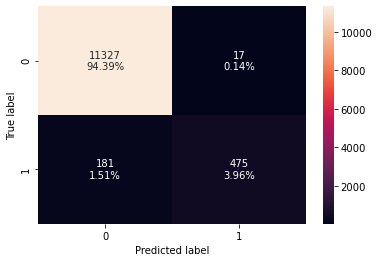

```python
# Calculating different metrics
bagging_classifier_model_train_perf = model_performance_classification_sklearn(
    bagging_classifier, X_train, y_train
)
print("Training performance:\n", bagging_classifier_model_train_perf)
bagging_classifier_model_test_perf = model_performance_classification_sklearn(
    bagging_classifier, X_val, y_val
)
print("Validation performance:\n", bagging_classifier_model_test_perf)
# Creating confusion matrix
confusion_matrix_sklearn(bagging_classifier, X_val, y_val)
```

#### Decision Tree

```python
dtree = DecisionTreeRegressor(random_state=1)
dtree.fit(X_train, y_train)
```

```
DecisionTreeRegressor(random_state=1)
```

```
Training performance:
    Accuracy  Recall  Precision   F1  Minimum_Vs_Model_cost
0       1.0     1.0        1.0  1.0                    1.0
Validation performance:
    Accuracy    Recall  Precision        F1  Minimum_Vs_Model_cost
0  0.970583  0.745427   0.724444  0.734786               0.658414
```

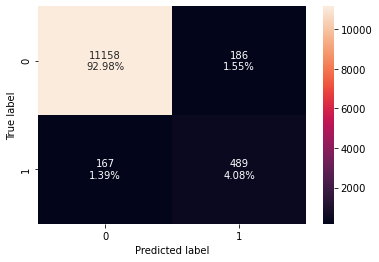

```python
dtree_model_train_perf = model_performance_classification_sklearn(
    dtree, X_train, y_train
)
print("Training performance:\n", dtree_model_train_perf)
dtree_model_test_perf = model_performance_classification_sklearn(dtree, X_val, y_val)
print("Validation performance:\n", dtree_model_test_perf)
# Creating confusion matrix
confusion_matrix_sklearn(dtree, X_val, y_val)
```

#### Random Forest

```
Training performance:
    Accuracy    Recall  Precision        F1  Minimum_Vs_Model_cost
0  0.999964  0.999347        1.0  0.999673               0.998913
Testing performance:
    Accuracy   Recall  Precision        F1  Minimum_Vs_Model_cost
0  0.986583  0.76372   0.988166  0.861565               0.715897
```

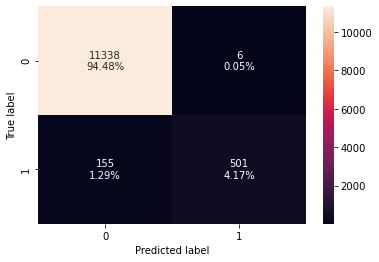

```python
#Fitting the model
rf_estimator = RandomForestClassifier(random_state=1)
rf_estimator.fit(X_train,y_train)

#Calculating different metrics
rf_estimator_model_train_perf=model_performance_classification_sklearn(rf_estimator,X_train,y_train)
print("Training performance:\n",rf_estimator_model_train_perf)
rf_estimator_model_test_perf=model_performance_classification_sklearn(rf_estimator,X_val,y_val)
print("Testing performance:\n",rf_estimator_model_test_perf)

#Creating confusion matrix
confusion_matrix_sklearn(rf_estimator, X_val, y_val)
```

#### Gradient Boost Model

```
Training performance:
    Accuracy    Recall  Precision        F1  Minimum_Vs_Model_cost
0  0.987214  0.782495   0.979558  0.870007                0.73102
Validation performance:
    Accuracy    Recall  Precision        F1  Minimum_Vs_Model_cost
0  0.982083  0.719512    0.93837  0.814495               0.674203
```

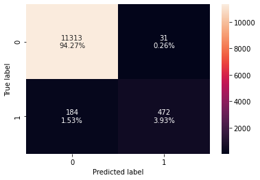

```python
# Fitting the model
gdb = GradientBoostingClassifier(random_state=1)
gdb.fit(X_train, y_train)

# Calculating different metrics
gdb_model_train_perf = model_performance_classification_sklearn(gdb, X_train, y_train)
print("Training performance:\n", gdb_model_train_perf)
gdb_model_test_perf = model_performance_classification_sklearn(gdb, X_val, y_val)
print("Validation performance:\n", gdb_model_test_perf)

# Creating confusion matrix
confusion_matrix_sklearn(gdb, X_val, y_val)
```

#### AdaBoost Model

```
Training performance:
    Accuracy    Recall  Precision        F1  Minimum_Vs_Model_cost
0  0.975714  0.627041   0.898036  0.738462               0.607781
Validation performance:
    Accuracy    Recall  Precision        F1  Minimum_Vs_Model_cost
0  0.971667  0.605183   0.830544  0.700176               0.588517
```

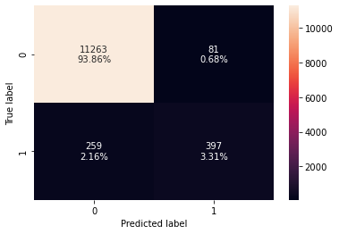

```python
# Fitting the model
ada = AdaBoostClassifier(random_state=1)
ada.fit(X_train, y_train)

# Calculating different metrics
ada_model_train_perf = model_performance_classification_sklearn(ada, X_train, y_train)
print("Training performance:\n", ada_model_train_perf)
ada_model_test_perf = model_performance_classification_sklearn(ada, X_val, y_val)
print("Validation performance:\n", ada_model_test_perf)

# Creating confusion matrix
confusion_matrix_sklearn(ada, X_val, y_val)
```

#### XGB Boost Model

```
[08:01:12] WARNING: C:/Users/Administrator/workspace/xgboost-win64_release_1.4.0/src/learner.cc:1095: Starting in XGBoost 1.3.0, the default evaluation metric used with the objective 'binary:logistic' was changed from 'error' to 'logloss'. Explicitly set eval_metric if you'd like to restore the old …
Training performance:
    Accuracy  Recall  Precision   F1  Minimum_Vs_Model_cost
0       1.0     1.0        1.0  1.0                    1.0
Validation performance:
    Accuracy    Recall  Precision        F1  Minimum_Vs_Model_cost
0  0.989583  0.824695   0.981851  0.896437               0.770858
```

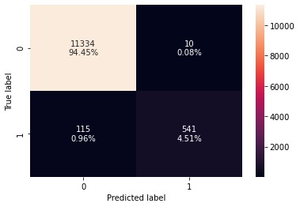

```python
# Fitting the model
xgb = XGBClassifier(random_state=1)
xgb.fit(X_train, y_train)

# Calculating different metrics
xgb_model_train_perf = model_performance_classification_sklearn(xgb, X_train, y_train)
print("Training performance:\n", xgb_model_train_perf)
xgb_model_test_perf = model_performance_classification_sklearn(xgb, X_val, y_val)
print("Validation performance:\n", xgb_model_test_perf)

# Creating confusion matrix
confusion_matrix_sklearn(xgb, X_val, y_val)
```

### Observations on Models using original data

- All of the models show very good confusion matrix predications
- Most of the models perform very well on the training set and show slight drops in metrics and min vs model cost on the validation data.
- The XGB boost method has the highest metrics in both training and validation data as well as having high validation data min vs model cost of close to our target of 0.78

## Model Building with Oversampled data

```python
# Synthetic Minority Over Sampling Technique
sm = SMOTE(sampling_strategy=1, k_neighbors=5, random_state=1)
X_train_over, y_train_over = sm.fit_resample(X_train, y_train)
```

#### Bagging Classifier

```python
# Bagging Classifier
bagging_classifier_over = BaggingClassifier(random_state=1)
bagging_classifier_over.fit(X_train_over, y_train_over)
```

```
BaggingClassifier(random_state=1)
```

```
Training performance:
    Accuracy    Recall  Precision        F1  Minimum_Vs_Model_cost
0  0.999226  0.998602   0.999849  0.999225               0.997626
Validation performance:
    Accuracy    Recall  Precision        F1  Minimum_Vs_Model_cost
0  0.983833  0.841463   0.859813  0.850539               0.763382
```

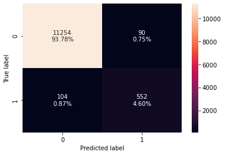

```python
# Calculating different metrics
bagging_classifier_over_model_train_perf = model_performance_classification_sklearn(
    bagging_classifier_over, X_train_over, y_train_over
)
print("Training performance:\n", bagging_classifier_over_model_train_perf)
bagging_classifier_over_model_test_perf = model_performance_classification_sklearn(
    bagging_classifier_over, X_val, y_val
)
print("Validation performance:\n", bagging_classifier_over_model_test_perf)
# Creating confusion matrix
confusion_matrix_sklearn(bagging_classifier_over, X_val, y_val)
```

#### Decision Tree

```python
# Decision Tree
dtree_over = DecisionTreeRegressor(random_state=1)
dtree_over.fit(X_train_over, y_train_over)
```

```
DecisionTreeRegressor(random_state=1)
```

```
Training performance:
    Accuracy  Recall  Precision   F1  Minimum_Vs_Model_cost
0       1.0     1.0        1.0  1.0                    1.0
Validation performance:
    Accuracy  Recall  Precision        F1  Minimum_Vs_Model_cost
0  0.947833  0.8125   0.514479  0.630024               0.637719
```

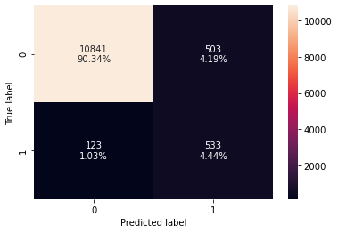

```python
dtree_model_over_train_perf = model_performance_classification_sklearn(
    dtree_over, X_train_over, y_train_over
)
print("Training performance:\n", dtree_model_over_train_perf)
dtree_model_over_test_perf = model_performance_classification_sklearn(
    dtree_over, X_val, y_val
)
print("Validation performance:\n", dtree_model_over_test_perf)
# Creating confusion matrix
confusion_matrix_sklearn(dtree_over, X_val, y_val)
```

#### Random Forest

```
Training performance:
    Accuracy  Recall  Precision   F1  Minimum_Vs_Model_cost
0       1.0     1.0        1.0  1.0                    1.0
Testing performance:
    Accuracy   Recall  Precision        F1  Minimum_Vs_Model_cost
0  0.990083  0.86128   0.952782  0.904724               0.802938
```

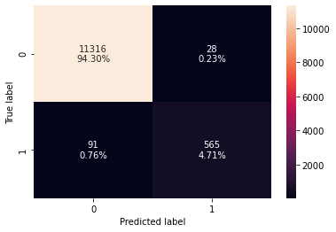

```python
# Fitting the model
rf_over_estimator = RandomForestClassifier(random_state=1)
rf_over_estimator.fit(X_train_over, y_train_over)

# Calculating different metrics
rf_over_estimator_model_train_perf = model_performance_classification_sklearn(
    rf_over_estimator, X_train_over, y_train_over
)
print("Training performance:\n", rf_over_estimator_model_train_perf)
rf_over_estimator_model_test_perf = model_performance_classification_sklearn(
    rf_over_estimator, X_val, y_val
)
print("Testing performance:\n", rf_over_estimator_model_test_perf)

# Creating confusion matrix
confusion_matrix_sklearn(rf_over_estimator, X_val, y_val)
```

#### Gradient Boost

```
Training performance:
    Accuracy    Recall  Precision        F1  Minimum_Vs_Model_cost
0  0.945427  0.917828   0.971449  0.943878               0.872643
Validation performance:
    Accuracy    Recall  Precision        F1  Minimum_Vs_Model_cost
0  0.966167  0.876524   0.638889  0.739075               0.729429
```

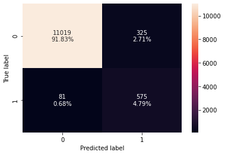

```python
# Fitting the model
gdb_over = GradientBoostingClassifier(random_state=1)
gdb_over.fit(X_train_over, y_train_over)

# Calculating different metrics
gdb_over_model_train_perf = model_performance_classification_sklearn(
    gdb_over, X_train_over, y_train_over
)
print("Training performance:\n", gdb_over_model_train_perf)
gdb_over_model_test_perf = model_performance_classification_sklearn(
    gdb_over, X_val, y_val
)
print("Validation performance:\n", gdb_over_model_test_perf)

# Creating confusion matrix
confusion_matrix_sklearn(gdb_over, X_val, y_val)
```

#### Ada Boost Model

```
Training performance:
    Accuracy    Recall  Precision       F1  Minimum_Vs_Model_cost
0  0.907326  0.897654    0.91536  0.90642               0.834554
Validation performance:
    Accuracy    Recall  Precision        F1  Minimum_Vs_Model_cost
0  0.908083  0.853659   0.357371  0.503824               0.569609
```

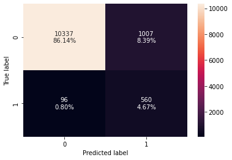

```python
# Fitting the model
ada_over = AdaBoostClassifier(random_state=1)
ada_over.fit(X_train_over, y_train_over)

# Calculating different metrics
ada_over_model_train_perf = model_performance_classification_sklearn(
    ada_over, X_train_over, y_train_over
)
print("Training performance:\n", ada_over_model_train_perf)
ada_over_model_test_perf = model_performance_classification_sklearn(
    ada_over, X_val, y_val
)
print("Validation performance:\n", ada_over_model_test_perf)

# Creating confusion matrix
confusion_matrix_sklearn(ada_over, X_val, y_val)
```

#### XGB Boost Model

```
[08:00:22] WARNING: C:/Users/Administrator/workspace/xgboost-win64_release_1.4.0/src/learner.cc:1095: Starting in XGBoost 1.3.0, the default evaluation metric used with the objective 'binary:logistic' was changed from 'error' to 'logloss'. Explicitly set eval_metric if you'd like to restore the old …
Training performance:
    Accuracy    Recall  Precision       F1  Minimum_Vs_Model_cost
0   0.99915  0.998867   0.999433  0.99915               0.997926
Validation performance:
    Accuracy  Recall  Precision        F1  Minimum_Vs_Model_cost
0     0.988   0.875   0.902516  0.888545               0.806557
```

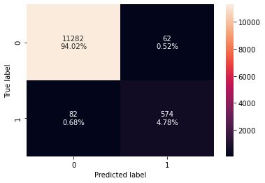

```python
# Fitting the model
xgb_over = XGBClassifier(random_state=1)
xgb_over.fit(X_train_over, y_train_over)

# Calculating different metrics
xgb_over_model_train_perf = model_performance_classification_sklearn(
    xgb_over, X_train_over, y_train_over
)
print("Training performance:\n", xgb_over_model_train_perf)
xgb_over_model_test_perf = model_performance_classification_sklearn(
    xgb_over, X_val, y_val
)
print("Validation performance:\n", xgb_over_model_test_perf)

# Creating confusion matrix
confusion_matrix_sklearn(xgb_over, X_val, y_val)
```

### Observations on Models using Over Sampled Data

- Across the models the performance has improved for the majority.
- AdaBoost has decreased performance metrics when compared to the original data.
- Random Forest, Bagging Classifier, and XGB Boost are showing the best performance.

## Model Building with Undersampled data

```python
# Random undersampler for under sampling the data
rus = RandomUnderSampler(random_state=1, sampling_strategy=1)
X_train_un, y_train_un = rus.fit_resample(X_train, y_train)
```

#### Bagging Classifier

```
Training performance:
    Accuracy    Recall  Precision        F1  Minimum_Vs_Model_cost
0  0.987263  0.977139   0.997333  0.987133                0.96249
Validation performance:
    Accuracy    Recall  Precision        F1  Minimum_Vs_Model_cost
0  0.947917  0.867378   0.514002  0.645491                0.66916
```

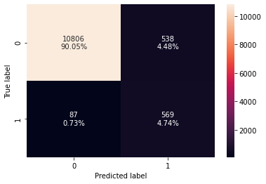

```python
# Bagging Classifier
bagging_classifier_un = BaggingClassifier(random_state=1)
bagging_classifier_un.fit(X_train_un, y_train_un)

# Calculating different metrics
bagging_classifier_un_model_train_perf = model_performance_classification_sklearn(
    bagging_classifier_un, X_train_un, y_train_un
)
print("Training performance:\n", bagging_classifier_un_model_train_perf)
bagging_classifier_un_model_test_perf = model_performance_classification_sklearn(
    bagging_classifier_un, X_val, y_val
)
print("Validation performance:\n", bagging_classifier_un_model_test_perf)
# Creating confusion matrix
confusion_matrix_sklearn(bagging_classifier_un, X_val, y_val)
```

#### Decision Tree Model

```
Training performance:
    Accuracy  Recall  Precision   F1  Minimum_Vs_Model_cost
0       1.0     1.0        1.0  1.0                    1.0
Validation performance:
    Accuracy    Recall  Precision        F1  Minimum_Vs_Model_cost
0   0.85325  0.838415   0.249433  0.384481               0.473874
```

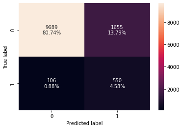

```python
# Decision Tree
dtree_un = DecisionTreeRegressor(random_state=1)
dtree_un.fit(X_train_un, y_train_un)

dtree_model_un_train_perf = model_performance_classification_sklearn(
    dtree_un, X_train_un, y_train_un
)
print("Training performance:\n", dtree_model_un_train_perf)
dtree_model_un_test_perf = model_performance_classification_sklearn(
    dtree_un, X_val, y_val
)
print("Validation performance:\n", dtree_model_un_test_perf)
# Creating confusion matrix
confusion_matrix_sklearn(dtree_un, X_val, y_val)
```

#### Random Forest

```
Training performance:
    Accuracy  Recall  Precision   F1  Minimum_Vs_Model_cost
0       1.0     1.0        1.0  1.0                    1.0
Testing performance:
    Accuracy    Recall  Precision        F1  Minimum_Vs_Model_cost
0    0.9655  0.887195   0.631236  0.737643               0.734877
```

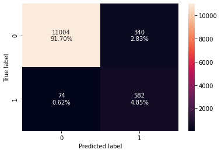

```python
# Fitting the model
rf_un_estimator = RandomForestClassifier(random_state=1)
rf_un_estimator.fit(X_train_un, y_train_un)

# Calculating different metrics
rf_un_estimator_model_train_perf = model_performance_classification_sklearn(
    rf_un_estimator, X_train_un, y_train_un
)
print("Training performance:\n", rf_un_estimator_model_train_perf)
rf_un_estimator_model_test_perf = model_performance_classification_sklearn(
    rf_un_estimator, X_val, y_val
)
print("Testing performance:\n", rf_un_estimator_model_test_perf)

# Creating confusion matrix
confusion_matrix_sklearn(rf_un_estimator, X_val, y_val)
```

#### Gradient Boost

```
Training performance:
    Accuracy    Recall  Precision        F1  Minimum_Vs_Model_cost
0  0.987214  0.782495   0.979558  0.870007                0.73102
Validation performance:
    Accuracy    Recall  Precision        F1  Minimum_Vs_Model_cost
0  0.982083  0.719512    0.93837  0.814495               0.674203
```

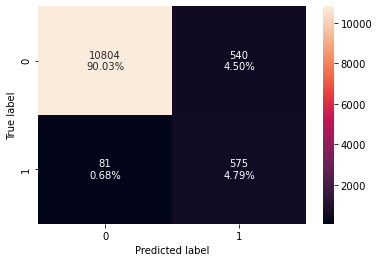

```python
# Fitting the model
gdb_un = GradientBoostingClassifier(random_state=1)
gdb_un.fit(X_train_un, y_train_un)

# Calculating different metrics
gdb_un_model_train_perf = model_performance_classification_sklearn(
    gdb_un, X_train_un, y_train_un
)
print("Training performance:\n", gdb_model_train_perf)
gdb_un_model_test_perf = model_performance_classification_sklearn(gdb_un, X_val, y_val)
print("Validation performance:\n", gdb_model_test_perf)

# Creating confusion matrix
confusion_matrix_sklearn(gdb_un, X_val, y_val)
```

#### Ada Boost

```
Training performance:
    Accuracy    Recall  Precision       F1  Minimum_Vs_Model_cost
0  0.906597  0.881777   0.927835  0.90422               0.819739
Validation performance:
    Accuracy    Recall  Precision        F1  Minimum_Vs_Model_cost
0    0.8965  0.862805   0.329453  0.476832               0.551261
```

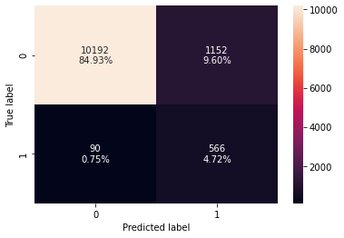

```python
# Fitting the model
ada_un = AdaBoostClassifier(random_state=1)
ada_un.fit(X_train_un, y_train_un)

# Calculating different metrics
ada_un_model_train_perf = model_performance_classification_sklearn(
    ada_un, X_train_un, y_train_un
)
print("Training performance:\n", ada_un_model_train_perf)
ada_un_model_test_perf = model_performance_classification_sklearn(ada_un, X_val, y_val)
print("Validation performance:\n", ada_un_model_test_perf)

# Creating confusion matrix
confusion_matrix_sklearn(ada_un, X_val, y_val)
```

#### XGB Boost

```
[08:29:27] WARNING: C:/Users/Administrator/workspace/xgboost-win64_release_1.4.0/src/learner.cc:1095: Starting in XGBoost 1.3.0, the default evaluation metric used with the objective 'binary:logistic' was changed from 'error' to 'logloss'. Explicitly set eval_metric if you'd like to restore the old …
Training performance:
    Accuracy  Recall  Precision   F1  Minimum_Vs_Model_cost
0       1.0     1.0        1.0  1.0                    1.0
Validation performance:
    Accuracy    Recall  Precision       F1  Minimum_Vs_Model_cost
0   0.96725  0.891768   0.644983  0.74856               0.744045
```

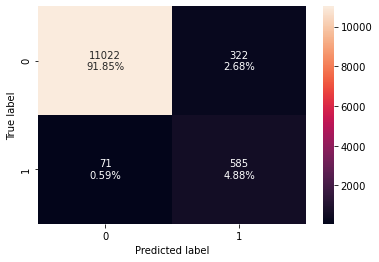

```python
# Fitting the model
xgb_un = XGBClassifier(random_state=1)
xgb_un.fit(X_train_un, y_train_un)

# Calculating different metrics
xgb_un_model_train_perf = model_performance_classification_sklearn(
    xgb_un, X_train_un, y_train_un
)
print("Training performance:\n", xgb_un_model_train_perf)
xgb_un_model_test_perf = model_performance_classification_sklearn(xgb_un, X_val, y_val)
print("Validation performance:\n", xgb_un_model_test_perf)

# Creating confusion matrix
confusion_matrix_sklearn(xgb_un, X_val, y_val)
```

## HyperparameterTuning

- **Hyperparameter tuning can take a long time to run, so to avoid that time complexity - you can use the following grids, wherever required.**

#### For XGBoost:

param_grid={'n_estimators':np.arange(150,300,50),'scale_pos_weight':[5,10], 'learning_rate':[0.1,0.2], 'gamma':[0,3,5], 'subsample':[0.8,0.9]}

#### For Gradient Boosting:

param_grid = { "init": [AdaBoostClassifier(random_state=1),DecisionTreeClassifier(random_state=1)], "n_estimators": np.arange(75,150,25), "learning_rate": [0.2, 0.05, 1], "subsample":[0.5,0.7], "max_features":[0.5,0.7]}

#### For Adaboost:

param_grid = { "n_estimators": np.arange(10, 110, 20), "learning_rate": [ 0.2, 0.05, 1], "base_estimator": [ DecisionTreeClassifier(max_depth=1, random_state=1), DecisionTreeClassifier(max_depth=2, random_state=1), DecisionTreeClassifier(max_depth=3, random_state=1)]}

#### For logistic Regression:

param_grid = {'C': np.arange(0.1,1.1,0.1)}

#### For Bagging Classifier:

param_grid = { 'max_samples': [0.8,0.9], 'max_features': [0.8,0.9], 'n_estimators' : [40,50]}

#### For Random Forest:

param_grid = { "n_estimators": [150,250], "min_samples_leaf": np.arange(1, 3), "max_features": ['sqrt','log2'], "max_samples": np.arange(0.2, 0.6, 0.1)}

#### For Decision Trees:

param_grid = {'max_depth': np.arange(2,20), 'min_samples_leaf': [1, 2, 5, 7], 'max_leaf_nodes' : [5, 10,15], 'min_impurity_decrease': [0.0001,0.001] }

#### XGB Boost tuning on OverSampled Training Data

```python
# defining model
model = XGBClassifier(random_state=1, eval_metric="logloss")

# Parameter grid to pass in RandomizedSearchCV
param_grid = {
    "n_estimators": np.arange(150, 300, 50),
    "scale_pos_weight": [5, 10],
    "learning_rate": [0.1, 0.2],
    "gamma": [0, 3, 5],
    "subsample": [0.8, 0.9],
}
#'max_depth':np.arange(1,5,1),
#'reg_lambda':[5,10]}


# Type of scoring used to compare parameter combinations
scorer = metrics.make_scorer(metrics.recall_score)

# Calling RandomizedSearch
xgb_tuned_cv = RandomizedSearchCV(
    estimator=model,
    param_distributions=param_grid,
    n_iter=50,
    scoring=scorer,
    cv=5,
    random_state=1,
    n_jobs=-1,
)

# Fitting parameters in RandomizedSearch
xgb_tuned_cv.fit(X_train_over, y_train_over)


print(
    "Best parameters are {} with CV score={}:".format(
        xgb_tuned_cv.best_params_, xgb_tuned_cv.best_score_
    )
)
```

```
Best parameters are {'subsample': 0.8, 'scale_pos_weight': 10, 'n_estimators': 250, 'learning_rate': 0.1, 'gamma': 5} with CV score=0.9956553162608432:
```

```python
# Building XGB Boost model with tuned parameters
# building model with best parameters
xgb_tuned1 = XGBClassifier(
    random_state=1,
    n_estimators=250,
    scale_pos_weight=10,
    subsample=0.8,
    learning_rate=0.1,
    gamma=5,
    eval_metric="logloss",
)

# Fit the model on training data
xgb_tuned1.fit(X_train_over, y_train_over)
```

```
XGBClassifier(base_score=0.5, booster='gbtree', colsample_bylevel=1,
              colsample_bynode=1, colsample_bytree=1, eval_metric='logloss',
              gamma=5, gpu_id=-1, importance_type='gain',
              interaction_constraints='', learning_rate=0.1, max_delta_step=0,
              max_depth=6, min_child_weight=1, missing=nan,
              monotone_constraints='()', n_estimators=250, n_jobs=8,
              num_parallel_tree=1, random_state=1, reg_alpha=0, reg_lambda=1,
              scale_pos_weight=10, subsample=0.8, tree_method='exact',
              validate_parameters=1, verbosity=None)
```

```
Training performance:
    Accuracy  Recall  Precision       F1  Minimum_Vs_Model_cost
0  0.991509     1.0   0.983301  0.99158               0.994371
Validation performance:
    Accuracy    Recall  Precision        F1  Minimum_Vs_Model_cost
0     0.975  0.896341   0.717073  0.796748               0.774803
```

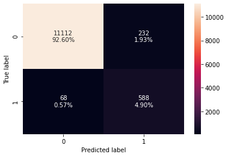

```python
# Calculating different metrics
xgb_tuned_model_train_perf = model_performance_classification_sklearn(
    xgb_tuned1, X_train_un, y_train_un
)
print("Training performance:\n", xgb_tuned_model_train_perf)
xgb_tuned_model_val_perf = model_performance_classification_sklearn(
    xgb_tuned1, X_val, y_val
)
print("Validation performance:\n", xgb_tuned_model_val_perf)

# Creating confusion matrix
confusion_matrix_sklearn(xgb_tuned1, X_val, y_val)
```

- XGB Boost with tuned hyperparameters on the Over Sampled Data has very strong results.
- Good Validation metrics as well as a min vs model cost of 0.77

#### Random Forest Tuned On OverSampled Data

```python
# defining model
model = RandomForestClassifier(random_state=1)

# Parameter grid to pass in RandomizedSearchCV
param_grid = {
    "n_estimators": [150, 250],
    "min_samples_leaf": np.arange(1, 3),
    "max_features": ["sqrt", "log2"],
    "max_samples": np.arange(0.2, 0.6, 0.1),
}


# Type of scoring used to compare parameter combinations
scorer = metrics.make_scorer(metrics.recall_score)

# Calling RandomizedSearch
rf_tuned_cv = RandomizedSearchCV(
    estimator=model,
    param_distributions=param_grid,
    n_iter=50,
    scoring=scorer,
    cv=5,
    random_state=1,
    n_jobs=-1,
)

# Fitting parameters in RandomizedSearch
rf_tuned_cv.fit(X_train_over, y_train_over)


print(
    "Best parameters are {} with CV score={}:".format(
        rf_tuned_cv.best_params_, rf_tuned_cv.best_score_
    )
)
```

```
Best parameters are {'n_estimators': 250, 'min_samples_leaf': 1, 'max_samples': 0.5000000000000001, 'max_features': 'log2'} with CV score=0.9752163705533488:
```

```python
# Building Random Forest model with tuned parameters
# building model with best parameters
rf_tuned1 = RandomForestClassifier(
    random_state=1,
    n_estimators=250,
    max_samples=0.5000000000000001,
    max_features="log2",
)

# Fit the model on training data
rf_tuned1.fit(X_train_over, y_train_over)
```

```
RandomForestClassifier(max_features='log2', max_samples=0.5000000000000001,
                       n_estimators=250, random_state=1)
```

```
Training performance:
    Accuracy    Recall  Precision        F1  Minimum_Vs_Model_cost
0  0.998999  0.998375   0.999622  0.998998               0.997175
Validation performance:
    Accuracy    Recall  Precision        F1  Minimum_Vs_Model_cost
0   0.99025  0.871951   0.945455  0.907216               0.812887
```

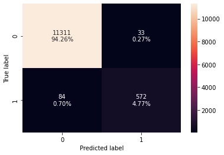

```python
# Metrics on Random Forest tuned
# Calculating different metrics
rf_tuned_model_train_perf = model_performance_classification_sklearn(
    rf_tuned1, X_train_over, y_train_over
)
print("Training performance:\n", rf_tuned_model_train_perf)
rf_tuned_model_val_perf = model_performance_classification_sklearn(
    rf_tuned1, X_val, y_val
)
print("Validation performance:\n", rf_tuned_model_val_perf)

# Creating confusion matrix
confusion_matrix_sklearn(rf_tuned1, X_val, y_val)
```

#### Bagging Tuned Model

```python
# defining model
model = BaggingClassifier(random_state=1)

# Parameter grid to pass in RandomizedSearchCV
param_grid = {
    "max_samples": [0.8, 0.9],
    "max_features": [0.8, 0.9],
    "n_estimators": [40, 50],
}


# Type of scoring used to compare parameter combinations
scorer = metrics.make_scorer(metrics.recall_score)

# Calling RandomizedSearch
bag_tuned_cv = RandomizedSearchCV(
    estimator=model,
    param_distributions=param_grid,
    n_iter=50,
    scoring=scorer,
    cv=5,
    random_state=1,
    n_jobs=-1,
)

# Fitting parameters in RandomizedSearch
bag_tuned_cv.fit(X_train_over, y_train_over)


print(
    "Best parameters are {} with CV score={}:".format(
        bag_tuned_cv.best_params_, bag_tuned_cv.best_score_
    )
)
```

```
Best parameters are {'n_estimators': 50, 'max_samples': 0.9, 'max_features': 0.8} with CV score=0.9794854256832217:
```

```python
# Bagging Classifier model with best parameters

bag_tuned1 = BaggingClassifier(
    random_state=1,
    n_estimators=50,
    max_samples=0.9,
    max_features=0.8,
)

# Fit the model on training data
bag_tuned1.fit(X_train_over, y_train_over)
```

```
BaggingClassifier(max_features=0.8, max_samples=0.9, n_estimators=50,
                  random_state=1)
```

```
Training performance:
    Accuracy    Recall  Precision        F1  Minimum_Vs_Model_cost
0  0.999981  0.999962        1.0  0.999981               0.999937
Validation performance:
    Accuracy    Recall  Precision        F1  Minimum_Vs_Model_cost
0  0.987833  0.856707   0.915309  0.885039               0.790361
```

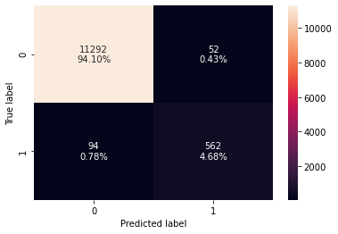

```python
# Metrics on bagging

# Calculating different metrics
bag_tuned_model_train_perf = model_performance_classification_sklearn(
    bag_tuned1, X_train_over, y_train_over
)
print("Training performance:\n", bag_tuned_model_train_perf)
bag_tuned_model_val_perf = model_performance_classification_sklearn(
    bag_tuned1, X_val, y_val
)
print("Validation performance:\n", bag_tuned_model_val_perf)

# Creating confusion matrix
confusion_matrix_sklearn(bag_tuned1, X_val, y_val)
```

## Model Performance comparison and choosing the final model

```python
# training performance comparison

models_train_comp_df = pd.concat(
    [
        bag_tuned_model_train_perf.T,
        rf_tuned_model_train_perf.T,
        xgb_tuned_model_train_perf.T,
    ],
    axis=1,
)
models_train_comp_df.columns = [
    "Bagging Tuned with Random search",
    "Random Forest Tuned with Random search",
    "Xgboost Tuned with Random Search",
]
print("Training performance comparison:")
models_train_comp_df
```

```
Training performance comparison:
```

|  | Bagging Tuned with Random search | Random Forest Tuned with Random search | Xgboost Tuned with Random Search |
| --- | --- | --- | --- |
| Accuracy | 0.999981 | 0.998999 | 0.991509 |
| Recall | 0.999962 | 0.998375 | 1.000000 |
| Precision | 1.000000 | 0.999622 | 0.983301 |
| F1 | 0.999981 | 0.998998 | 0.991580 |
| Minimum_Vs_Model_cost | 0.999937 | 0.997175 | 0.994371 |

```python
# Validation performance comparison

models_val_comp_df = pd.concat(
    [
        bag_tuned_model_val_perf.T,
        rf_tuned_model_val_perf.T,
        xgb_tuned_model_val_perf.T,
    ],
    axis=1,
)
models_val_comp_df.columns = [
    "Bagging Tuned with Random search",
    "Random Forest Tuned with Random search",
    "Xgboost Tuned with Random Search",
]
print("Validation performance comparison:")
models_val_comp_df
```

```
Validation performance comparison:
```

|  | Bagging Tuned with Random search | Random Forest Tuned with Random search | Xgboost Tuned with Random Search |
| --- | --- | --- | --- |
| Accuracy | 0.987833 | 0.990250 | 0.975000 |
| Recall | 0.856707 | 0.871951 | 0.896341 |
| Precision | 0.915309 | 0.945455 | 0.717073 |
| F1 | 0.885039 | 0.907216 | 0.796748 |
| Minimum_Vs_Model_cost | 0.790361 | 0.812887 | 0.774803 |

- Random Forest with tuned hyperparameters on the oversampled data is showing the best metrics as well as min vs model cost of 0.81 on the validation set.
- We will put this model into the test data to check performance.

## Test set final performance

```python
testing = pd.read_csv("Test.csv")

# replace missing values with median values
data2 = testing.apply(lambda x: x.fillna(x.median()), axis=0)

X_test = data2.drop(columns="Target")


Y_test = data2["Target"]
```

```python
# Calculating different metrics on the test set
rf_tuned_test = model_performance_classification_sklearn(rf_tuned1, X_test, Y_test)
print("Test performance:")
rf_tuned_test
```

```
Test performance:
```

|  | Accuracy | Recall | Precision | F1 | Minimum_Vs_Model_cost |
| --- | --- | --- | --- | --- | --- |
| 0 | 0.9896 | 0.862888 | 0.942116 | 0.900763 | 0.802445 |

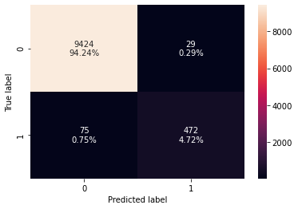

```python
# creating confusion matrix
confusion_matrix_sklearn(rf_tuned1, X_test, Y_test)
```

- Final Model Observations:
  - Scored very well with good accuracy, recall and precision as well as min vs model cost >0.78

### Final Model Feature Importance

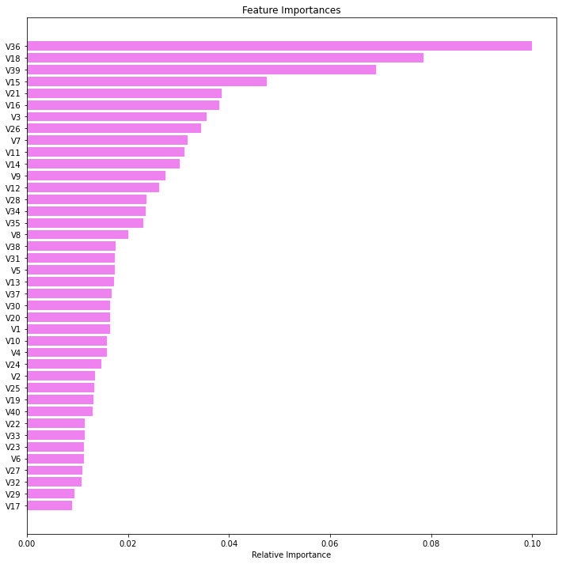

```python
feature_names = X.columns
importances = rf_tuned1.feature_importances_
indices = np.argsort(importances)

plt.figure(figsize=(12, 12))
plt.title("Feature Importances")
plt.barh(range(len(indices)), importances[indices], color="violet", align="center")
plt.yticks(range(len(indices)), [feature_names[i] for i in indices])
plt.xlabel("Relative Importance")
plt.show()
```

#### Observations

- V36, V18 and V39 are the most impactful predictors for failing instrumentation